# R을 이용한 텍스트 파일 처리 기초 02

Ji-Myoung Choi

2023-02

### 3회차에서 배울 내용

- 데이터프레임(data frame)은 행과 열을 가진 n x n 테이블로 엑셀의 스프레드시트와 유사한 구조를 가진 데이터 유형이다.
- 텍스트 데이터를 저장하고 메타 정보를 이용하여 검색하기 위해 많이 사용하는 데이터 유형이다.
- 데이터프레임은 1개 이상의 벡터를 칼럼으로 가지는 데이터 형식이다.
- data frame을 엑셀이나 csv 포맷 등으로 내보내거나 엑셀, csv 파일을 data frame으로 읽어들일 수 있다.
- **apply()** 계열의 함수를 이용하여 일괄 처리를 하는 방법을 배운다.

[figure not shown]

#### 1. dataframe 만들기

- dataframe은 벡터를 이용해 만들 수 있다.

```r
vec_1 <- c("a", "b", "c")
vec_2 <- c(1, 2, 3)
vec_3 <- c(TRUE, FALSE, TRUE)

df <- data.frame(vec_1, vec_2, vec_3)
print(df)
```

```
##   vec_1 vec_2 vec_3
## 1     a     1  TRUE
## 2     b     2 FALSE
## 3     c     3  TRUE
```

1. 1-3행: 벡터 3개를 *vec_1, 2, 3* 이름으로 만든다.
2. 5행: **data.frame()** 함수로 3개 벡터를 dataframe으로 만든 후 *df*에 할당한다. dataframe의 열로 사용할 벡터들을 항으로 주면 된다.
3. 6행: *df*를 출력한다. vec_1, vec_2, vec_3를 열로 가지는 dataframe이 생성되었음을 알 수 있다.

```r
vec_1 <- c("a", "b", "c")
vec_2 <- c(1, 2, 3)
vec_3 <- c(TRUE, FALSE, TRUE)

df <- data.frame(char = vec_1, number = vec_2, logical = vec_3)
print(df)
```

```
##   char number logical
## 1    a      1    TRUE
## 2    b      2   FALSE
## 3    c      3    TRUE
```

1. 1-3행: 벡터 3개를 *vec_1, 2, 3* 이름으로 만든다.
2. 5행: **data.frame()** 함수로 3개 벡터를 dataframe으로 만든 후 *df*에 할당한다. 이 때 열의 이름 char, number, logical을 지정하였다.
3. 6행: *df*를 출력한다. char, number, logical가 열의 이름으로 된 dataframe이 생성되었음을 알 수 있다.

```r
vec_1 <- c("a", "b", "c")
vec_2 <- c(1, 2, 3)
vec_3 <- c(TRUE, FALSE, TRUE)

df <- data.frame(vec_1, vec_2, vec_3)
colnames(df) <- c("char", "number", "logical")
rownames(df) <- c("seq_1", "seq_2", "seq_3")
print(df)
```

```
##       char number logical
## seq_1    a      1    TRUE
## seq_2    b      2   FALSE
## seq_3    c      3    TRUE
```

1. 1-3행: 벡터 3개를 *vec_1, 2, 3* 이름으로 만든다.
2. 5행: **data.frame()** 함수로 3개 벡터를 dataframe으로 만든 후 *df*에 할당한다.
3. 6-7행: *df*에 열과 행의 이름을 할당한다. 열 이름은 **colnames()** 함수, 행 이름은 **rownames()** 함수를 이용한다. 이 때 행과 열의 수와 이름의 수가 같아야 한다.
4. 8행: *df*를 출력한다.

```r
dim(df)
```

```
## [1] 3 3
```

```r
nrow(df)
```

```
## [1] 3
```

```r
ncol(df)
```

```
## [1] 3
```

1. dataframe의 차원(dimension)을 알기 위해 **dim()** 함수를 사용한다.
2. dataframe의 행의 갯수를 알기 위해 **nrow()** 함수를 사용한다. 결과는 **dim(df)[1]**과 같다.
3. dataframe의 열의 갯수를 알기 위해 **ncol()** 함수를 사용한다. 결과는 **dim(df)[2]**와 같다.

#### 2. data frame 검색하기 (retrieval, querying)

- dataframe은 subsetting 기호 [ ]를 사용하여 검색한다. 2차원 데이터이므로 [행이름, 열이름] 혹은 [행번호, 열번호]와 같이 행과 열의 이름이나 인덱스를 이용해 검색한다.

```r
df["seq_1", ]
```

```
##       char number logical
## seq_1    a      1    TRUE
```

```r
df[, "char"]
```

```
## [1] "a" "b" "c"
```

```r
df["seq_1", "char"]
```

```
## [1] "a"
```

```r
df[1, ]
```

```
##       char number logical
## seq_1    a      1    TRUE
```

```r
df[, 1]
```

```
## [1] "a" "b" "c"
```

```r
df[1, 1]
```

```
## [1] "a"
```

```r
df[1:2, 1:2]
```

```
##       char number
## seq_1    a      1
## seq_2    b      2
```

1. 1-4행: 행과 열의 이름 대신 인덱스를 이용하여 *df*의 부분을 출력한다.

```r
df$char
```

```
## [1] "a" "b" "c"
```

```r
df$number
```

```
## [1] 1 2 3
```

1. dataframe의 열 정보는 $ 기호와 열의 이름을 이용하여 얻을 수도 있다.

#### 3. 열(column)과 행(row) 추가하기

##### 행(row) 추가하기: **rbind()**

```r
df_row_added <- rbind(df, seq_4 = c("d", 4, FALSE))
print(df_row_added)
```

```
##       char number logical
## seq_1    a      1    TRUE
## seq_2    b      2   FALSE
## seq_3    c      3    TRUE
## seq_4    d      4   FALSE
```

1. 1행: **rbind()** 함수로 seq_4라는 이름을 가지는 행 c(“d”, 4, FALSE)를 추가한다.
2. 2행: *df_row_added*를 출력한다.

##### 열(column) 추가하기: **cbind()**

```r
df_col_added <- cbind(df, symbol = c("@", "#", "&"))
print(df_col_added)
```

```
##       char number logical symbol
## seq_1    a      1    TRUE      @
## seq_2    b      2   FALSE      #
## seq_3    c      3    TRUE      &
```

1. 1행: **cbind()** 함수로 symbol이라는 이름을 가지는 열 c(“@”, “#”, “&”)를 추가한다.
2. 2행: *df_col_added*를 출력한다.

```r
df_col_added <- df
df_col_added$symbol <- c("@", "#", "&")
print(df_col_added)
```

```
##       char number logical symbol
## seq_1    a      1    TRUE      @
## seq_2    b      2   FALSE      #
## seq_3    c      3    TRUE      &
```

1. 1행: *df_col_added*라는 빈 변수를 만들어 *df*를 복사한다.
2. 2행: dataframe의 열은 $ 기호로 검색 가능하다. 이를 이용햐 새 열을 만들어 넣을 수 있다. *df_col_added*에 symbol이라는 열을 만들고 거기에 벡터 c(“@”, “#”, “&”)를 삽입한다.
3. 3행: *df_col_added*를 출력한다.

#### 4. 행과 열 삭제하기: 인덱스 이용하기

```r
df_row_removed <- df_row_added[-4,]
print(df_row_removed)
```

```
##       char number logical
## seq_1    a      1    TRUE
## seq_2    b      2   FALSE
## seq_3    c      3    TRUE
```

1. 1행: *df_row_added*에서 4번째 행을 삭제하기 위해서는 해당 인덱스 번호 4에 - 기호를 붙이면 된다. 매트릭스는 행과 열로 구성되므로 [행 번호, 열 번호] 구조를 이용한다. 삭제 후 *df_row_removed*에 저장한다.
2. 2행: *df_row_removed*를 출력한다.

```r
df_col_removed <- df_col_added[, -4]
print(df_col_removed)
```

```
##       char number logical
## seq_1    a      1    TRUE
## seq_2    b      2   FALSE
## seq_3    c      3    TRUE
```

1. 1행: *df_col_added*에서 4번째 열을 삭제하기 위해서는 해당 인덱스 번호 4에 - 기호를 붙이면 된다. 매트릭스는 행과 열로 구성되므로 [행 번호, 열 번호] 구조를 이용한다. 삭제 후 *df_col_removed*에 저장한다.
2. 2행: *df_col_removed*를 출력한다.

#### 6. Dataframe 파일에 쓰기/읽기: 엑셀 및 csv(comma separated values) 파일

```r
# install.packages(c("writexl", "readxl"))
library(writexl)

write.csv(df, "result/df_test.csv")
write_xlsx(df, "result/df_test.xlsx")
```

1. 1행: 엑셀 파일을 읽고 쓰기 위해 필요한 라이브러리 writexl과 readxl을 설치한다. 설치되어 있을 경우 1행은 생략한다.
2. 2행: 필요한 라이브러리를 탑재하기 위해서 **library()** 함수를 이용한다.
3. 4행: 데이터프레임이나 매트릭스를 csv 포맷으로 저장할 때는 **write.csv()** 함수를 이용한다. 저장할 개체와 저장할 파일 경로를 함수의 항으로 사용한다.
4. 5행: 데이터프레임이나 매트릭스를 xlsx 포맷으로 저장할 때는 **write_xlsx()** 함수를 이용한다. 저장할 개체와 저장할 파일 경로를 함수의 항으로 사용한다.

#### 7. Dataframe 읽어서 검색해 보기

```r
library(readxl)
# install.packages("knitr")
library(knitr)

# filepath <- "data/top_250_movie.csv"
filepath <- "data/top_250_movie.xlsx"
# top_250_movie <- read.csv(filepath)
top_250_movie <- read_xlsx(filepath)
kable(head(top_250_movie))
```

| 제목 | 영화_url | 순위 | 상영연도 | 평점 |
| --- | --- | --- | --- | --- |
| 쇼생크 탈출 | https://www.imdb.com/title/tt0111161/ | 1 | 1994 | 9.2 |
| Daeboo | https://www.imdb.com/title/tt0068646/ | 2 | 1972 | 9.2 |
| 다크 나이트 | https://www.imdb.com/title/tt0468569/ | 3 | 2008 | 9.0 |
| The Godfather Part II | https://www.imdb.com/title/tt0071562/ | 4 | 1974 | 9.0 |
| 12명의 성난 사람들 | https://www.imdb.com/title/tt0050083/ | 5 | 1957 | 9.0 |
| 쉰들러 리스트 | https://www.imdb.com/title/tt0108052/ | 6 | 1993 | 8.9 |

1. 1행: 라이브러리 readxl을 탑재한다.
2. 3행: dataframe 모양을 정돈할 수 있는 라이브러리 knitr를 탑재한다(* 보통은 이 라이브러릴 사용하지 않아도 됨).
3. 6행: 읽어올 엑셀 파일의 위치를 *filepath*에 지정한다.
4. 8행: **read_xlsx()** 함수로 엑셀 파일을 읽어 *top_250_movie*에 저장한다.
5. 9행: *top_250_movie*의 첫 6행을 출력한다.

##### ’평점’이 9.0 이상인 열의 정보만 검색 출력하기

```r
kable(top_250_movie[top_250_movie$평점 >= 9.0,])
```

| 제목 | 영화_url | 순위 | 상영연도 | 평점 |
| --- | --- | --- | --- | --- |
| 쇼생크 탈출 | https://www.imdb.com/title/tt0111161/ | 1 | 1994 | 9.2 |
| Daeboo | https://www.imdb.com/title/tt0068646/ | 2 | 1972 | 9.2 |
| 다크 나이트 | https://www.imdb.com/title/tt0468569/ | 3 | 2008 | 9.0 |
| The Godfather Part II | https://www.imdb.com/title/tt0071562/ | 4 | 1974 | 9.0 |
| 12명의 성난 사람들 | https://www.imdb.com/title/tt0050083/ | 5 | 1957 | 9.0 |

```r
# top_250_movie[which(top_250_movie\$평점 >= 9.0),]
```

1. 1행: dataframe인 *top_250_movie*의 정보를 검색해서 해당하는 행과 열을 추출하는 것이므로 subsetting 기호인 […]를 사용한다. subsetting의 조건은 ‘평점’ 열의 값에서 9.0 이상인 것만 찾아서 TRUE/FALSE 논리값을 얻은 후 이를 *top_250_movie*에 적용한다.
2. 2행: top_250_movie[which(top_250_movie$평점 >= 9.0),] 과 같이 실행해도 된다. **which()* 함수를 사용하면 인덱스 값을 얻을 수 있다는 점이 차이이다.

##### ’평점’이 9.0 미만이면서 8.7 이상인 열의 정보만 검색 출력하기

```r
kable(top_250_movie[which(top_250_movie$평점 < 9.0 & top_250_movie$평점 >= 8.7),])
```

| 제목 | 영화_url | 순위 | 상영연도 | 평점 |
| --- | --- | --- | --- | --- |
| 쉰들러 리스트 | https://www.imdb.com/title/tt0108052/ | 6 | 1993 | 8.9 |
| 반지의 제왕: 왕의 귀환 | https://www.imdb.com/title/tt0167260/ | 7 | 2003 | 8.9 |
| 펄프 픽션 | https://www.imdb.com/title/tt0110912/ | 8 | 1994 | 8.8 |
| 반지의 제왕: 반지 원정대 | https://www.imdb.com/title/tt0120737/ | 9 | 2001 | 8.8 |
| 석양의 무법자 | https://www.imdb.com/title/tt0060196/ | 10 | 1966 | 8.8 |
| 포레스트 검프 | https://www.imdb.com/title/tt0109830/ | 11 | 1994 | 8.8 |
| 파이트 클럽 | https://www.imdb.com/title/tt0137523/ | 12 | 1999 | 8.7 |
| The Lord of the Rings: The Two Towers | https://www.imdb.com/title/tt0167261/ | 13 | 2002 | 8.7 |
| 인셉션 | https://www.imdb.com/title/tt1375666/ | 14 | 2010 | 8.7 |
| 스타워즈 에피소드 5 - 제국의 역습 | https://www.imdb.com/title/tt0080684/ | 15 | 1980 | 8.7 |
| 매트릭스 | https://www.imdb.com/title/tt0133093/ | 16 | 1999 | 8.7 |
| 좋은 친구들 | https://www.imdb.com/title/tt0099685/ | 17 | 1990 | 8.7 |

```r
# top_250_movie[top_250_movie$평점 < 9.0 & top_250_movie$평점 >= 8.7,]
```

1. 1행: 두 개의 조건을 “그리고(and)” 방식으로 묶을 경우 두 개 조건을 & 기호로 연결한다.

##### ’평점’이 8.0을 초과하면서 ’상영연도’가 2020년 이후인 열의 정보만 검색 출력하기

```r
kable(top_250_movie[which(top_250_movie$평점 > 8.0 & top_250_movie$상영연도 >= 2020),])
```

| 제목 | 영화_url | 순위 | 상영연도 | 평점 |
| --- | --- | --- | --- | --- |
| 탑건: 매버릭 | https://www.imdb.com/title/tt1745960/ | 94 | 2022 | 8.3 |
| Hamilton | https://www.imdb.com/title/tt8503618/ | 107 | 2020 | 8.2 |
| 더 파더 | https://www.imdb.com/title/tt10272386/ | 130 | 2020 | 8.2 |
| 스파이더맨: 노 웨이 홈 | https://www.imdb.com/title/tt10872600/ | 148 | 2021 | 8.1 |

1. 1행: 두 개의 조건을 “그리고(and)” 방식으로 묶을 경우 두 개 조건을 & 기호로 연결한다.

##### ’평점’이 8.8을 초과하거나(or) ’상영연도’가 2020년 이후인 열의 정보만 검색 출력하기

```r
top_250_movie[which(top_250_movie$평점 > 8.8 | top_250_movie$상영연도 >= 2020),]
```

```
## # A tibble: 12 × 5
##    제목                   영화_url                           순위 상영연도  평점
##    <chr>                  <chr>                             <dbl>    <dbl> <dbl>
##  1 쇼생크 탈출            https://www.imdb.com/title/tt011…     1     1994   9.2
##  2 Daeboo                 https://www.imdb.com/title/tt006…     2     1972   9.2
##  3 다크 나이트            https://www.imdb.com/title/tt046…     3     2008   9
##  4 The Godfather Part II  https://www.imdb.com/title/tt007…     4     1974   9
##  5 12명의 성난 사람들     https://www.imdb.com/title/tt005…     5     1957   9
##  6 쉰들러 리스트          https://www.imdb.com/title/tt010…     6     1993   8.9
##  7 반지의 제왕: 왕의 귀환 https://www.imdb.com/title/tt016…     7     2003   8.9
##  8 탑건: 매버릭           https://www.imdb.com/title/tt174…    94     2022   8.3
##  9 Hamilton               https://www.imdb.com/title/tt850…   107     2020   8.2
## 10 더 파더                https://www.imdb.com/title/tt102…   130     2020   8.2
## 11 스파이더맨: 노 웨이 홈 https://www.imdb.com/title/tt108…   148     2021   8.1
## 12 Jai Bhim               https://www.imdb.com/title/tt150…   229     2021   8
```

1. 1행: 두 개의 조건을 “또는(or)” 방식으로 묶을 경우 두 개 조건을 | 기호로 연결한다.

##### ’제목’이 정확히 Daeboo와 일치하는 열만 검색 출력하기

```r
top_250_movie[which(top_250_movie$제목 == "Daeboo"),]
```

```
## # A tibble: 1 × 5
##   제목   영화_url                               순위 상영연도  평점
##   <chr>  <chr>                                 <dbl>    <dbl> <dbl>
## 1 Daeboo https://www.imdb.com/title/tt0068646/     2     1972   9.2
```

1. 1행: 같다/다르다 조건은 == 그리고 != 와 같이 표현한다.

##### ’제목’에 ’ment’라는 문자열이 포함된 열만 검색 출력하기

```r
top_250_movie[grep("ment", top_250_movie$제목),]
```

```
## # A tibble: 2 × 5
##   제목                       영화_url                        순위 상영연도  평점
##   <chr>                      <chr>                          <dbl>    <dbl> <dbl>
## 1 Terminator 2: Judgment Day https://www.imdb.com/title/tt…    29     1991   8.5
## 2 The Apartment              https://www.imdb.com/title/tt…   102     1960   8.2
```

1. 1행: 정확히 같은 문자열을 찾는 것이 아니라 일부 문자열이 일치하는 것을 찾는 것이므로 **grep()** 함수를 이용할 수 있다.

##### 조건에 맞는 행의 인덱스 얻기

```r
ids <- which(top_250_movie$평점 >= 9.0)
print(ids)
```

```
## [1] 1 2 3 4 5
```

#### 8. 소설에서 빈도 정보 추출하기

```r
txt <- scan("data/plain_docs/english_novels/moby_dick_melville.txt", what = "character", sep = "\n")
start_id <- which(txt == "CHAPTER 1. Loomings.")[2]
novel_lines <- txt[start_id:length(txt)]
```

1. 1행: moby_dick_melville.txt 파일을 읽어 *txt*에 저장한다.
2. 2행: 소설의 본문만 남기고 다른 부분(header, footer)을 삭제하기 위해 본문의 시작 위치를 찾는다. 이 파일에서 본문의 시작은 첫 번째 챕터가 시작되는 곳이므로, **which()** 함수로 “CHAPTER 1. Loomings.”라는 문자열이 위치한 인덱스를 구한다. 시작 위치는 *start_id*에 저장한다. **grep()** 함수를 이용할 수도 있다.
3. 3행: 시작 위치인 *start_id*부터 소설의 마지막 라인(**length(txt)**)까지 subsetting하면([start_id:length(txt)]) 헤더 부분을 제외한 나머지 부분만 남길 수 있다.

```r
words <- unlist(strsplit(novel_lines, split = " "))
freqs <- table(words)
freqs <- sort(freqs, decreasing = TRUE)
print(freqs[1:10])
```

```
## words
##   the    of   and     a    to    in  that   his     I  with
## 13615  6487  5886  4456  4448  3817  2652  2394  1713  1663
```

1. 1행: *novel_lines*를 공백 기준으로 단어로 분리하고(**strsplit()**), 이 결과들을 모두 벡터로 변환한다(**unlist()**). 전체 라인들에서 얻은 전체 단어를 *words*에 저장한다.
2. 2행: 벡터 요소들의 빈도를 구할 때는 **table()** 함수를 사용한다. **table()** 함수의 결과물은 각 단어의 빈도와 각 단어 이름으로 된 벡터이다.
3. 3행: 이 빈도 정보는 단어 이름의 알파벳순으로 정렬이 되므로 빈도를 기준으로 제정렬하기 위해 **sort()** 함수를 사용하고, 빈도의 내림차순으로 정렬할 것이므로 **decreasing** 항을 TRUE로 설정한다.
4. 4행: *freqs*를 1부터 10번째까지 출력한다.

```r
words <- unlist(strsplit(novel_lines, split = " "))
words <- tolower(words)
words <- gsub(pattern = "[[:punct:]]", replacement = " ", x = words)
words <- gsub(pattern = " +", replacement = " ", x = words)
freqs <- table(words)
freqs <- sort(freqs, decreasing = TRUE)
freqs_df <- as.data.frame(freqs)
kable(head(freqs_df, n = 10))
```

| words | Freq |
| --- | --- |
| the | 14159 |
| of | 6522 |
| and | 6202 |
| a | 4565 |
| to | 4511 |
| in | 4033 |
| that | 2709 |
| his | 2449 |
| it | 1754 |
| with | 1717 |

```r
# kable(freqs_df[1:10,])
```

1. 1행: *novel_lines*를 공백 기준으로 단어로 분리하고(**strsplit()**), 이 결과들을 모두 벡터로 변환한다(**unlist()**). 전체 라인들에서 얻은 전체 단어를 *words*에 저장한다.
2. 2행: 분리한 단어들을 모두 소문자로 변환한다(**tolower()**).
3. 3행: 정규식을 이용하여 모든 단어들에서 구두점(punctuations)을 공백으로 대체하고(**gsub()**) 다시 *words*에 저장한다.
4. 4행: 공백이 두 개 이상 연속으로 나오는 경우, 이를 삭제하기 위해 정규식을 이용한다.
5. 5행: *words*의 빈도를 구하여 *freqs*에 저장한다.
6. 6행: 빈도를 내림차순으로 정렬하여 *freqs*에 다시 저장한다.
7. 7행: **as.data.frame()** 함수로 *freqs*를 dataframe으로 변환하여 *freqs_df*에 저장한다.
8. 8행: *freqs_df*의 첫 10행만 출력한다.

##### 소설을 챕터 단위로 나누고 각 챕터에서 빈도 정보 추출하기

- 챕터 단위로 나누기 위해서는 각 챕터의 시작과 끝 위치를 먼저 파악하고
- 이 위치값을 이용하여 본문을 [시작위치:끝위치]로 분리한다.

```r
chap_position_ids <- grep("^CHAPTER \\d", novel_lines)
chap_position_ids <- c(chap_position_ids, grep("END OF THE PROJECT GUTENBERG EBOOK MOBY-DICK", novel_lines))
print(novel_lines[chap_position_ids][1:10])
```

```
##  [1] "CHAPTER 1. Loomings."        "CHAPTER 2. The Carpet-Bag."
##  [3] "CHAPTER 3. The Spouter-Inn." "CHAPTER 4. The Counterpane."
##  [5] "CHAPTER 5. Breakfast."       "CHAPTER 6. The Street."
##  [7] "CHAPTER 7. The Chapel."      "CHAPTER 8. The Pulpit."
##  [9] "CHAPTER 9. The Sermon."      "CHAPTER 10. A Bosom Friend."
```

1. 1행: 각 챕터는 “CHAPTER 1.”, “CHAPTER 2.” 등과 같이 시작한다. 따라서 챕터는 텍스트 라인이 “CHAPTER”로 시작하고 공백 후에 숫자가 오는 형태로 시작함을 알 수 있다. 이를 이용하여 **grep()** 함수와 정규식을 이용하여 모든 챕터의 위치 인덱스를 얻는다.
2. 2행: 챕터의 범위는 챕터가 시작하는 위치와 다음 챕터가 시작하는 위치 사이이다. 그렇지만 마지막 챕터의 범위는 [마지막 챕터의 시작 위치:본문의 마지막 위치]이다. 따라서 본문의 마지막 라인의 위치를 *chap_position_ids*에 따로 추가해 주어야 한다. 본문의 마지막 라인은 “END OF THE PROJECT GUTENBERG EBOOK MOBY-DICK”이 있는 라인 바로 앞까지이다.
3. 3행: *chap_position_ids*를 10행까지 출력한다.

###### 상대 빈도(relative frequency) 목록 구하기

```r
chapter_raws_l <- list()
chapter_freqs_l <- list()

for(i in 1:length(chap_position_ids)){
  if(i < length(chap_position_ids)){
    chapter_title <- novel_lines[chap_position_ids[i]]
    chapter_start <- chap_position_ids[i] + 1
    chapter_end <- chap_position_ids[i + 1] - 1
    chapter_lines <- novel_lines[chapter_start:chapter_end]

    chapter_words <- tolower(paste(chapter_lines, collapse = " "))
    chapter_words <- strsplit(chapter_words, " ")
    chapter_words <- unlist(chapter_words)
    chapter_words <- gsub(pattern = "[[:punct:]]", replacement = "", chapter_words)
    # chapter_words <- strsplit(chapter_words, "\\W")
    chapter_words <- chapter_words[which(chapter_words != "")]
    chapter_freqs <- table(chapter_words)

    chapter_raws_l[[chapter_title]] <- chapter_freqs
    chapter_freqs_rel <- 100*(chapter_freqs/sum(chapter_freqs))
    chapter_freqs_l[[chapter_title]] <- chapter_freqs_rel
  }
}
```

1. 1행: 챕터별 단어 빈도 목록을 저장할 리스트 *chapter_raws_l*를 만든다.
2. 2행: 챕터별 단어 상대 빈도 목록을 저장할 리스트 *chapter_freqs_l*를 만든다.
3. 4행: 1에서 **length(chap_position_ids)** 즉 마지막 챕터 위치까지 인덱스 번호를 만든 후 1주터 하나씩 *i*에 할당하고
4. 5행: 총 챕터의 수는 135개이다. 반면 *chap_position_ids*의 수는 136개인데, 이는 본문의 마지막 위치를 135개 챕터 시작 위치값에 추가했기 때문이다. 챕터 135개에서 단어 목록을 얻기 위해서는 135번째 챕터 위치값까지만 이용해야 한다. 따라서 *i*가 **length(chap_position_ids)**보다 작을 때까지만 **for** 구문을 실행해야 한다. 5행은 이 조건을 추가한 것이다. 즉 만약(**if**) *i*가 **length(chap_position_ids)**보다 작다면 {…} 내의 명령을 실행하고 그렇지 않으면 실행하지 않는다.
5. 6행: *chap_position_ids*는 챕터 제목의 위치값들이다. *i*번째 챕터의 제목을 먼저 얻는다. 이 제목은 1-2행에서 만든 빈 리스트에 챕터별로 단어 목록을 요소로 추가할 때 이 요소의 제목으로 사용한다.
6. 7행: 챕터 본문의 범위는 챕터 제목 다음 행부터 시작하여 다음 챕터 제목 이전 행까지이다. 7행에서는 챕터 본문 시작 위치를 구하기 위해 챕터 제목 다음 행의 위치를 구해 *chapter_start*에 저장한다.
7. 8행: 챕터 본문 마지막 위치를 구하기 위해 다음 챕터의 시작(*chap_position_ids[i + 1]*) 위치에서 1을 뺀 후 *chapter_end*에 저장한다.
8. 9행: 챕터의 시작 위치와 끝 위치를 구했으므로 *novel_lines[chapter_start:chapter_end]*로 챕터 본문을 얻을 수 있다. 본문은 *chapter_lines*에 저장한다.
9. 11-17행: 위 코드 블록에서와 같이 단어들의 빈도 목록을 구해 *chapter_freqs*에 저장한다. 16행의 **which(chapter_words != ““)**는 빈 벡터가 아닌 것 즉 단어가 들어있는 벡터 요소만을 찾기 위한 것이다.
10. 19행: *chapter_freqs*를 *chapter_raws_l*에 순차적으로 추가한다. 이 때 리스트 요소의 제목을 같이 저장한다.
11. 20행: 상대 빈도는 특정 단어가 전체 단어 중 어느 정도의 비율을 가지는지를 나타낸다. 상대 빈도를 구하는 공식은 <개별 빈도값 전체 빈도합>이다. 전체 빈도합은 **sum(chapter_freqs)**, 개별 빈도값은 *chapter_freqs*이다.
12. 21행: 상대 빈도값 목록 *chapter_freqs_rel*을 *chapter_freqs_l*에 저장한다. 이 전체 과정을 총 135번 반복하게 된다.

###### 각 챕터에서 특정 단어의 상대 빈도 얻기

```r
chapter_freqs_l[[1]]["whale"]
```

```
##     whale
## 0.1369863
```

```r
chapter_freqs_l[[2]]["whale"]
```

```
##      whale
## 0.07062147
```

```r
chapter_freqs_l[[3]]["whale"]
```

```
##      whale
## 0.05187619
```

```r
chapter_freqs_l[[135]]["whale"]
```

```
##     whale
## 0.5516656
```

1. 1행: 벡터와 달리 리스트에서 특정 요소에 접근할 때는 []가 아닌 [[]]를 사용한다. *chapter_freqs_l[[1]]*으로 첫 번째 챕터의 목록을 벡터로 가져올 수 있고 이 벡터에서 이름이 “whale”인 것의 빈도값을 가지고 와서 출력한다.
2. 2-4행: 2장, 3장, 135장의 빈도 목록을 각각 가지고 와서 각 벡터에서 이름이 “whale”인 것의 빈도값들을 출력한다.

###### **lapply()** 함수로 전체 목록에서 값 구하기

```r
whales <- lapply(chapter_freqs_l, "[", "whale")
```

1. 1행: **lapply()** 함수는 리스트에 대해 특정 함수를 일괄적으로 적용하는 함수이다. **for()** 구문 대신 사용할 수 있으며 속도가 조금 더 빠르고 간결하다. **lapply()** 함수는 리스트, 적용할 함수, (함수의 항) 등 2개 혹은 3개의 항을 가진다. 리스트에서 요소를 하나씩 가져와서 다음의 함수를 적용한 후 결과값을 반환한다. 여기서 리스트는 *chapter_freqs_l*, 적용할 함수는 ‘[’이다.’[’는 벡터의 요소를 subsetting하는 기능을 가지므로 함수 대신 사용할 수 있다. subsetting은 요소의 이름을 주어 원하는 것을 추출할 수도 있다. 다음의 **for()** 구분과 동일한 기능을 수행한다. 이 명령은 *chapter_freqs_l*에서 챕터별 빈도 목록을 하나씩 가져온 후 거기에서 “whale”이라는 이름을 가진 벡터 요소를 검색하여 반환하라는 의미이다.

```r
whales <- list()
for (i in 1:length(chapter_freqs_l)) {
  whale <- chapter_freqs_l[[i]]["whale"]
  whales[[i]] <- whale
}
```

1. 1행: 각 챕터에서 얻은 빈도값을 저장할 빈 리스트 *whales*를 만든다.
2. 2행: 1:length(chapter_freqs_l) 즉 1:135까지의 벡터에서 값을 하나씩 가져와서 *i*에 할당한 후
3. 3행: *chapter_freqs_l*의 *i*번째 요소 중에서 이름이 whale인 것([“whale”])의 값을 가져와서 *whale*에 저장한다.
4. 4행: 리스트 *whales*의 *i*번째 요소로 *whale*을 저장한다.

###### **do.call()** 함수로 리스트를 통합하기

```r
whales_m <- do.call(what = rbind, args = whales)
```

1. **do.call()** 함수는 어떤 특정 함수(첫번째 항(what))을 리스트(두번째 항(agrs))에 반복적으로 적용하는 함수이다. *whales*가 리스트로 된 챕터별 빈도이므로 이 빈도들을 135개의 행으로 만든다.

```r
ahabs <- lapply(chapter_freqs_l, "[", "ahab")
ahabs_m <- do.call(what = rbind, args = ahabs)
```

1. 1행: “ahab”이라는 단어의 챕터별 빈도를 구하여 리스트 *ahabs*에 저장한다.

```r
whales_ahabs_m <- cbind(whales_m, ahabs_m)
colnames(whales_ahabs_m) <- c("whale", "ahab")
head(whales_ahabs_m)
```

```
##                                  whale ahab
## CHAPTER 1. Loomings.        0.13698630   NA
## CHAPTER 2. The Carpet-Bag.  0.07062147   NA
## CHAPTER 3. The Spouter-Inn. 0.05187619   NA
## CHAPTER 4. The Counterpane.         NA   NA
## CHAPTER 5. Breakfast.               NA   NA
## CHAPTER 6. The Street.              NA   NA
```

1. 1행: **cbind()** 함수는 두 개 이상의 matrix나 dataframe을 열을 기준으로 하나로 합하여 하나의 matrix 혹은 dataframe으로 만들어주는 함수이다. 위에서 두 개의 matrix *whales_m*와 *ahabs_m*를 만들었다. 이 두 개를 합하여 *whales_ahabs_m*라는 matrix로 만든다.
2. 2행: **colnames()** 함수로 *whales_ahabs_m*의 두 개 열에 이름을 붙인다. 두 개 이상의 문자 이름을 주는 것이므로 **c()** 함수로 벡터를 만들어 이름으로 사용한다.
3. 3행: *whales_ahabs_m*의 첫 6행만 출력한다.

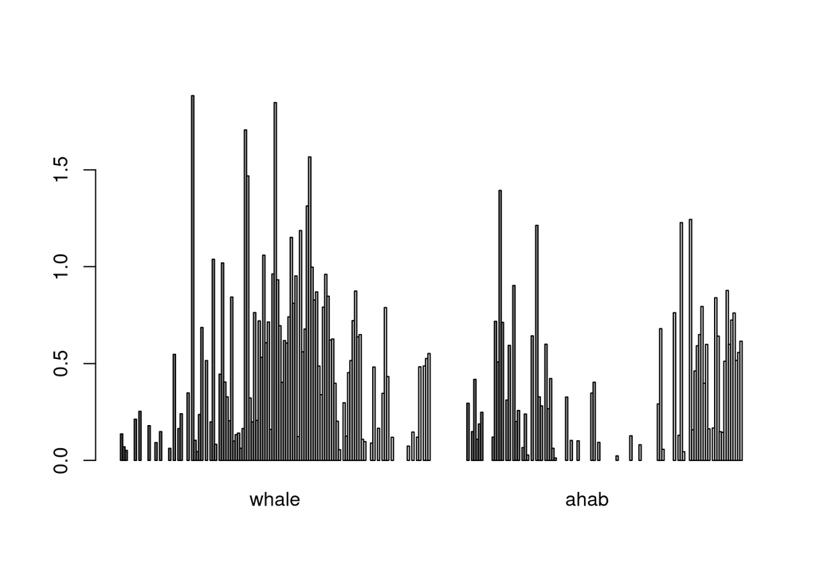

```r
barplot(whales_ahabs_m, beside = TRUE)
```

#### 9. apply 계열 함수

##### **apply()**: 매트릭스의 행이나 열에 특정 함수를 일괄적으로 적용할 때 사용

```r
mat <- matrix(data = 1:10, nrow = 5)
row_sums <- apply(mat, 1, sum)
col_sums <- apply(mat, 2, sum)
print(row_sums); print(col_sums)
```

```
## [1]  7  9 11 13 15
```

```
## [1] 15 40
```

1. 1행: **matrix()** 함수로 매트릭스를 만든다. 값은 1부터 10까지 그리고 행의 수는 5개로 설정한다. *mat*의 차원의 수는 5 x 2이다.
2. 2행: **apply()** 함수는 매트릭스, 행/열 기준, 적용 함수 등 3개의 항을 가진다. 이 명령은 *mat*에 대해 행을 기준으로 함수를 적용하되, 적용할 함수는 **sum()** 즉 총합을 구하는 함수를 적용하라는 의미이다.
3. 3행: *mat*에 대해 열을 기준으로 함수를 적용하되, 적용할 함수는 **sum()** 즉 총합을 구하는 함수를 적용하라는 의미이다.
4. 4행: *row_sums*는 총 5개의 수로 이루어진 벡터로, *col_sums*는 총 2개의 수로 이루어진 벡터가 출력된다. 이 값들은 각 행과 열의 합계이다.

##### **lapply()**: 리스트의 요소에 특정 함수를 일괄적으로 적용할 때 사용

```r
lst <- list(c(1, 2, 3, 4, 5), c(6, 7, 8, 9, 10))
elem_sums <- lapply(lst, sum)
print(elem_sums)
```

```
## [[1]]
## [1] 15
##
## [[2]]
## [1] 40
```

```r
# sapply(lst, sum)
```

1. 1행: ’1, 2, 3, 4, 5’로 이루어진 벡터와 ’6, 7, 8, 9, 10’으로 이루어진 벡터를 *lst*라는 리스트로 만든다. 이 리스트는 두 개의 요소, 즉 두 개의 벡터로 구성되어 있고, 리스트의 각 요소는 5개씩의 숫자로 되어 있다.
2. 2행: *lst*의 각 요소, 즉 각 벡터에 대해 **sum()**이라는 함수를 일괄 적용한다. 반환되는 값 역시 리스트이다.
3. 3행: *elem_sums*를 출력한다.
4. 4행: **lapply(lst, sum)**와 동일한 기능을 하지만 차이점은 반환되는 값이 벡터라는 점이다.

```r
lst <- list(c(1, 2, 3, 4, 5), c(6, 7, 8, 9, 10))
elemwise_sums <- unlist(Map(f = sum, lst[[1]], lst[[2]]))
print(elemwise_sums)
```

```
## [1]  7  9 11 13 15
```

1. 2행: **lapply()** 함수는 리스트의 요소, 즉 벡터 전체에 대해 함수를 적용하는 반면, **Map()** 함수는 리스트의 각 요소, 즉 벡터 내의 각 요소에 대해 함수를 적용한다. 여기서는각 벡터 내의 각 요소에 대해 개별적으로 **sum()** 함수를 적용한다. **Map()** 함수는 리스트를 반환하므로 **unlist()**를 이용하여 벡터로 변환한다.
2. 3행: *elemwise_sums*를 출력한다.

```r
x <- c(1, 2, 3, 4, 5)
y <- c(6, 7, 8, 9, 10)
z <- c(seq(11, 15))
m <- rbind(x, y, z)
print(m)
```

```
##   [,1] [,2] [,3] [,4] [,5]
## x    1    2    3    4    5
## y    6    7    8    9   10
## z   11   12   13   14   15
```

#### 10. bestseller 리스트 다뤄보기: 베스트셀러의 제목에서 자주 사용된 어휘를 추출

```r
bestseller <- read.csv("./data/only_bestseller_list_100years.csv")
summary(bestseller)
```

```
##       Year         Author             Title               Type
##  Min.   :1918   Length:992         Length:992         Length:992
##  1st Qu.:1942   Class :character   Class :character   Class :character
##  Median :1967   Mode  :character   Mode  :character   Mode  :character
##  Mean   :1967
##  3rd Qu.:1992
##  Max.   :2017
```

1. 1행: 베스트셀러 목록을 읽어 *bestseller*에 할당한다. 이 목록은 dataframe 형식이다.
2. 2행: 데이터 *bestseller*의 구조(내용)를 알기 위해 **summary()** 함수를 사용한다.

```r
bestseller_titles <- unlist(strsplit(bestseller$Title, split = " "))
bestseller_titles <- gsub("\\W+", "", bestseller_titles)
bestseller_titles <- sort(table(tolower(bestseller_titles)), decreasing = TRUE)
bestseller_titles[1:30]
```

```
##
##    the     of    and      a     in     to    man   girl    for    all   from
##    481    127     50     39     27     19     16     15     14     12     12
##     my     no     on   time   with heaven  house   this   last   love   gone
##     10     10     10     10     10      9      9      9      8      8      7
##     is    one street    two    war  woman    you
##      7      7      7      7      7      7      7      6
```

1. 1행: *bestseller*의 Title 행을 공백 기준으로 분리하여 단어 리스트들로 만들고, 이 리스트들을 *unlist()*로 벡터로 만든 후 *bestseller_titles*에 저장한다.
2. 2행: *bestseller_titles*에 저장된 모든 단어에서 문자(알파벳 및 숫자)가 아닌 것을 삭제한 후 다시 *bestseller_titles*에 저장한다.
3. 3행: *bestseller_titles*에 저장된 모든 단어를 소문자로 바꾸고(**tolower()**) **table()** 함수로 빈도를 구한 후 내림차순 정렬을 한다(**sort()**).
4. 4행: 정렬된 빈도를 1부터 30까지만 출력한다.

##### 단어 목록에서 stopwords 제외하기

```r
stpwords <- readLines("./data/stopword_lemma_list/NLTK_english_stopwords.txt")

bestseller_titles_cleaned <- bestseller_titles[!names(bestseller_titles) %in% stpwords]
bestseller_titles_cleaned_df <- as.data.frame(bestseller_titles_cleaned)
bestseller_titles_cleaned_df[1:10,]
```

```
##      Var1 Freq
## 1     man   16
## 2    girl   15
## 3    time   10
## 4  heaven    9
## 5   house    9
## 6    last    8
## 7    love    8
## 8    gone    7
## 9     one    7
## 10 street    7
```

1. 1행: NLTK_english_stopwords.txt 파일을 읽어 *stpwords*에 저장한다.
2. 3행: *bestseller_titles*에 저장된 빈도 리스트에서 stopwords가 아닌 것만 남기기 위해 **%in%**을 사용한다. **%in%**은 영어의 ” is in”의 의미이다. 즉 **names(bestseller_titles) %in% stpwords**는 “check if 단어 is in the stopwords”의 의미이다. 만약 in이면 TRUE, 그렇지 않으면 FALSE를 반환한다. **names()**는 변수에 저장된 요소들의 이름을 얻는 함수이다. *bestseller_titles*는 이름이 있는 숫자 벡터이므로 단어를 얻으려면 이 벡터의 이름들을 가져와야 한다. **!**는 opposite을 나타낸다. TRUE는 FALSE로, FALSE는 TRUE로 바꾼다. *bestseller_titles*에 저장된 단어들 중 *stpwords*에 없는 것을 찾으라는 의미이다. 정리된 값을 *bestseller_titles_cleaned*에 저장한다.
3. 4행: **table()** 함수로 만든 빈도는 **as.data.frame()** 함수를 이용하여 dataframe으로 만들 수 있다.
4. 5행: dataframe인 *bestseller_titles_cleaned_df*를 10행까지만 출력한다.

##### 연도별(10년 단위) 단어 목록 만들기

```r
decades <- bestseller$Year
decades <- decades - (decades %% 10)
bestseller$Decade <- decades

bestseller_decades <- split(bestseller, f = bestseller$Decade)

bestseller_titles_decades <- list()
for (dec in bestseller_decades) {
  wrds <- dec$Title
  wrds <- unlist(strsplit(wrds, split = " "))
  wrds <- tolower(gsub("\\W+", "", wrds))
  wrds_ <- wrds[!wrds %in% stpwords]
  freqs <- sort(table(wrds_), decreasing = TRUE)
  rel_freqs <- 100 * (freqs / length(wrds))
  freq_df <- data.frame(Year = rep(dec$Decade[1], length(freqs)), Word = names(freqs),
                        Freq = as.integer(freqs), Rel_freq = as.numeric(rel_freqs))
  bestseller_titles_decades[[as.character(dec$Decade[1])]] <- freq_df[1:10,]
}

bestseller_titles_decades <- do.call(rbind, bestseller_titles_decades)
write.csv(bestseller_titles_decades, "./result/bestseller_title_words_decades.csv", row.names = FALSE)
```